# Pet Cats UK

Ashley Platt & Hayley Caldwell

2023-04-28

```r
library(tidyverse)
```

```r
library(tidytuesdayR)
library(ggimage)
```

# Load the data

```r
tt <- tidytuesdayR::tt_load("2023-01-31")
```

```
## --- Compiling #TidyTuesday Information for 2023-01-31 ----
```

```
## --- There are 2 files available ---
```

```
## --- Starting Download ---
```

```
## --- Download complete ---
```

```r
pet_cats <- tt$cats_uk_reference
```

# Introduction to cats

Cats are small carnivorous mammals that are often kept as domesticated pets. They are known for their playful and independent personalities, as well as their ability to catch mice and other small animals. Domesticated cats come in a variety of breeds, sizes, and colors, and are often kept indoors as house pets or allowed to roam outside as outdoor pets. They are known for their sharp claws and teeth, which they use for hunting, climbing, and defending themselves. Cats are also popular for their soothing purring sound, which is often associated with relaxation and comfort.

# Explore the data

```r
glimpse(pet_cats)
```

```
## Rows: 101
## Columns: 16
## $ tag_id                        <chr> "Tommy-Tag", "Athena", "Ares", "Lola", "…
## $ animal_id                     <chr> "Tommy", "Athena", "Ares", "Lola", "Mave…
## $ animal_taxon                  <chr> "Felis catus", "Felis catus", "Felis cat…
## $ deploy_on_date                <dttm> 2017-06-03 01:02:09, 2017-06-24 01:02:1…
## $ deploy_off_date               <dttm> 2017-06-10 02:10:52, 2017-06-30 23:59:3…
## $ hunt                          <lgl> TRUE, TRUE, NA, TRUE, TRUE, TRUE, TRUE, …
## $ prey_p_month                  <dbl> 12.5, 3.0, 0.0, 3.0, 3.0, 3.0, 3.0, 17.5…
## $ animal_reproductive_condition <chr> "Neutered", "Spayed", "Neutered", "Spaye…
## $ animal_sex                    <chr> "m", "f", "m", "f", "m", "f", "m", "m", …
## $ hrs_indoors                   <dbl> 12.5, 7.5, 7.5, 17.5, 12.5, 12.5, 12.5, …
## $ n_cats                        <dbl> 2, 2, 2, 1, 1, 2, 3, 4, 2, 2, 1, 1, 1, 2…
## $ food_dry                      <lgl> TRUE, TRUE, TRUE, TRUE, TRUE, TRUE, TRUE…
## $ food_wet                      <lgl> TRUE, TRUE, TRUE, TRUE, TRUE, TRUE, TRUE…
## $ food_other                    <lgl> FALSE, FALSE, FALSE, FALSE, TRUE, TRUE, …
## $ study_site                    <chr> "UK", "UK", "UK", "UK", "UK", "UK", "UK"…
## $ age_years                     <dbl> 11, 3, 3, 10, 7, 7, 6, 2, 4, 4, 8, 1, 8,…
```

```r
# Summary statistics for numerical variables
summary(pet_cats$age_years)
```

```
##    Min. 1st Qu.  Median    Mean 3rd Qu.    Max.    NA's
##    0.00    3.00    5.00    5.42    8.00   16.00       1
```

```r
summary(pet_cats$n_cats)
```

```
##    Min. 1st Qu.  Median    Mean 3rd Qu.    Max.
##   1.000   1.000   2.000   2.079   3.000   4.000
```

```r
# Frequency table for categorical variable
table(pet_cats$animal_sex)
```

```
##
##  f  m
## 44 57
```

# Create a histogram of ages

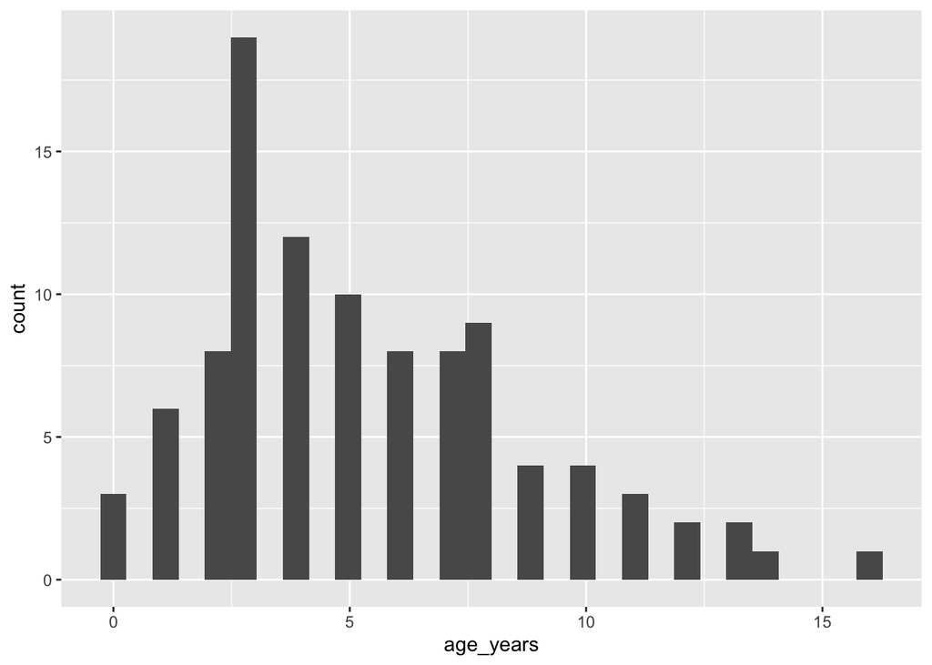

```r
ggplot(pet_cats, aes(x = age_years)) +
  geom_histogram()
```

Cat fact #1: The oldest recorded cat in history was named Creme Puff, who lived to be 38 years and 3 days old. This is equivalent to 169 cat years!